# R Programming I : Thinking, Fast and Slow

coop711

2019-03-19

## Monty Hall 문제

### 문항 배열 효과?

#### Red

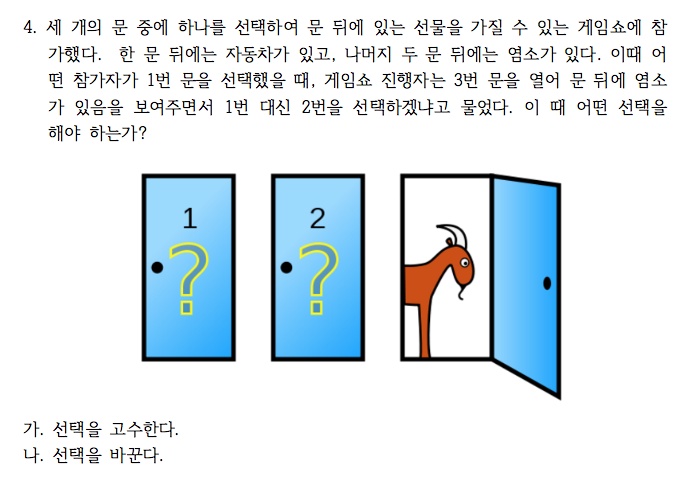

#### Black

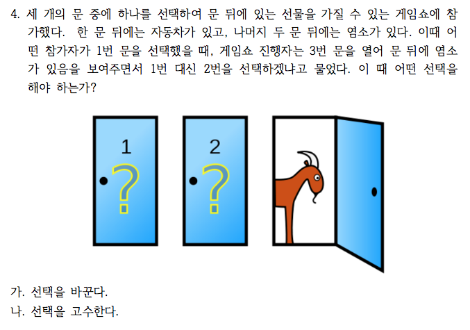

염소가 들어있는 문을 보여줌으로써 다른 문에 자동차가 들어 있을 확률은 2/3로 늘어나므로 바꾸는 것이 적절한 판단임. Red와 Black의 차이는 “바꾼다”와 “고수한다”의 순서를 바꾼 것으로 “바꾼다”를 앞에 놓은 Black 집단에서 바꾼다는 응답이 다소 높게 나왔으나 통계적으로 유의한 수준은 아님.

#### 집계

|  | 고수한다 | 바꾼다 | 결석 | 계 |
| --- | --- | --- | --- | --- |
| **Red** | 26 | 11 | 3 | 40 |
| **Black** | 24 | 13 | 1 | 38 |
| **계** | 50 | 24 | 4 | 78 |

Pearson’s Chi-squared test with simulated p-value (based on 2000 replicates): `.`

| Test statistic | df | P value |
| --- | --- | --- |
| 1.196 | NA | 0.6742 |

#### % 비교.

|  | 고수한다 | 바꾼다 | 계 |
| --- | --- | --- | --- |
| **Red** | 70.3 | 29.7 | 100.0 |
| **Black** | 64.9 | 35.1 | 100.0 |

#### 합산(%)

|  | 고수한다 | 바꾼다 | 계 |
| --- | --- | --- | --- |
| **계** | 67.6 | 32.4 | 100.0 |

## 내가 살고 싶은 세상

### 내가 남보다, 혹은 남이 나보다

#### Red

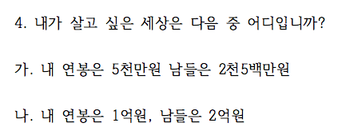

#### Black

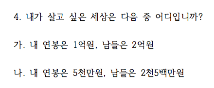

소득의 절대값이 아니라 상대 비교가 중요하다는 Solnick and Hemenway(1998)의 연구결과와 일치. 랜덤화하였지만 응답에는 차이가 없음.

#### 집계

|  | 내가 남보다 | 남이 나보다 | 결석 | 계 |
| --- | --- | --- | --- | --- |
| **Red(‘내가 남보다’ 먼저)** | 30 | 7 | 3 | 40 |
| **Black(‘남이 나보다’ 먼저)** | 32 | 5 | 1 | 38 |
| **계** | 62 | 12 | 4 | 78 |

#### % 비교.

|  | 내가 남보다 | 남이 나보다 | 계 |
| --- | --- | --- | --- |
| **Red(‘내가 남보다’ 먼저)** | 81.1 | 18.9 | 100.0 |
| **Black(‘남이 나보다’ 먼저)** | 86.5 | 13.5 | 100.0 |

#### 합산(%)

| 내가 남보다 | 남이 나보다 | 계 |
| --- | --- | --- |
| 83.8 | 16.2 | 100.0 |

## Wason Selection

### 추상적 표현과 구체적 표현?

같은 내용의 문제를 추상적으로 물어볼 때와 구체적으로 사례를 들어서 물어볼 때의 정답률에 큰 차이가 있음에 유의. Red 집단에게는 추상적 질문을 먼저 던지고, 구체적 사례를 든 질문을 나중에 던졌으며 Black 집단에게는 구체적 사례를 든 질문을 먼저 던지고, 추상적 질문을 나중에 던졌다. 동일한 질문에 대해서 순서에 따른 차이는 거의 없지만 추상적이냐 구체적이냐에 따른 차이는 매우 높게 관찰된다. 추상적인 질문에 쩔쩔매는 게 정상이다.

### Q3. Red에 추상적 문제 먼저 질문

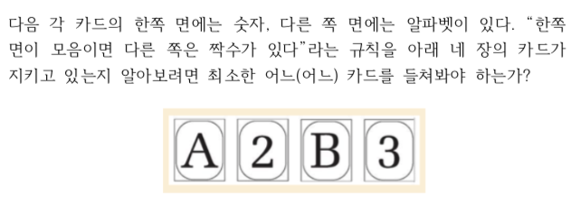

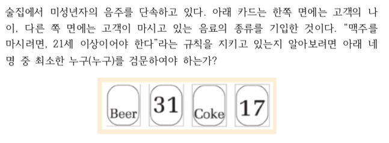

#### 집계

Wason Selection 1 in Red

|  | 정답 | 오답 | 결석 | 계 |
| --- | --- | --- | --- | --- |
| **Red(추상적 질문 먼저)** | 3 | 34 | 3 | 40 |
| **Black(구체적 질문 먼저)** | 27 | 10 | 1 | 38 |
| **계** | 30 | 44 | 4 | 78 |

#### % 비교

|  | 정답 | 오답 | 계 |
| --- | --- | --- | --- |
| **Red(추상적 질문 먼저)** | 8.1 | 91.9 | 100.0 |
| **Black(구체적 질문 먼저)** | 73.0 | 27.0 | 100.0 |

### Q4. Red에 구체적 문제 나중 질문

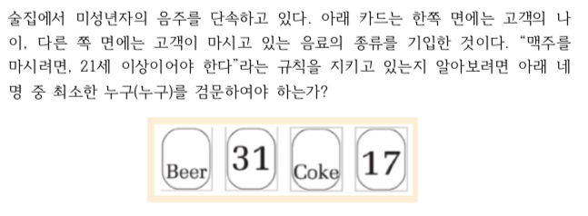

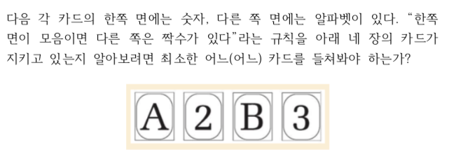

#### 집계

Wason Selection 1 in Black

|  | 정답 | 오답 | 결석 | 계 |
| --- | --- | --- | --- | --- |
| **Red(구체적 질문 나중)** | 21 | 15 | 4 | 40 |
| **Black(추상적 질문 나중)** | 1 | 36 | 1 | 38 |
| **계** | 22 | 51 | 5 | 78 |

#### % 비교.

|  | 정답 | 오답 | 계 |
| --- | --- | --- | --- |
| **Red(구체적 질문 나중)** | 58.3 | 41.7 | 100.0 |
| **Black(추상적 질문 나중)** | 2.7 | 97.3 | 100.0 |

### 합산

#### 집계표

Wason Selection

|  | 정답 | 오답 | 결석 | 계 |
| --- | --- | --- | --- | --- |
| **Wason 1(추상적 질문)** | 4 | 70 | 4 | 78 |
| **Wason 2(구체적 질문)** | 48 | 25 | 5 | 78 |

#### % 비교

Wason Selection

|  | 정답 | 오답 | 계 |
| --- | --- | --- | --- |
| **Wason 1(추상적 질문)** | 5.4 | 94.6 | 100.0 |
| **Wason 2(구체적 질문)** | 65.8 | 34.2 | 100.0 |

## Cognitive Response Test

### 시스템1과 시스템2

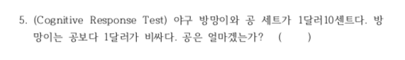

Cognitive Response Test 의 원형으로 얼핏 10센트라고 하기 쉬우나 (시스템1의 작용) 신중하게 생각하면(시스템2의 작용) 5센트인 것을 알게 됨. 하버드, MIT, 프린스턴 대학 학생의 50% 이상이 직관적 오답을 말했던데 비하여 여러분은 매우 심사숙고함.

#### 집계

|  | 5센트 | 10센트 | 결석 | 계 |
| --- | --- | --- | --- | --- |
| **Red** | 29 | 7 | 4 | 40 |
| **Black** | 28 | 7 | 3 | 38 |
| **계** | 57 | 14 | 7 | 78 |

#### % 비교.

|  | 5센트 | 10센트 | 계 |
| --- | --- | --- | --- |
| **Red** | 80.6 | 19.4 | 100.0 |
| **Black** | 80.0 | 20.0 | 100.0 |

## Prospect Theory

### 이득과 손실

#### Red

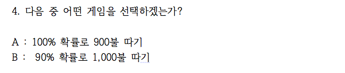

#### Black

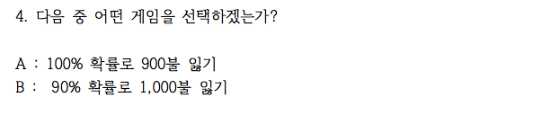

이득은 완전히 하고, 손실은 피하고자 하는 경향 확인. Red는 이득을 완전히 확보하려는 게임(A)에, Black은 손실을 확률적으로 피하려는 게임(B)을 많이 선택.

#### 집계

|  | 확률 100% | 확률 90% | 결석 | 계 |
| --- | --- | --- | --- | --- |
| **이득 게임** | 28 | 8 | 4 | 40 |
| **손실 게임** | 10 | 27 | 1 | 38 |
| **계** | 38 | 35 | 5 | 78 |

#### % 비교.

|  | 확률 100% | 확률 90% | 계 |
| --- | --- | --- | --- |
| **이득 게임** | 77.8 | 22.2 | 100.0 |
| **손실 게임** | 27.0 | 73.0 | 100.0 |

## Framing Effect

### 삶과 죽음

#### Red

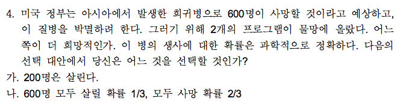

#### Black

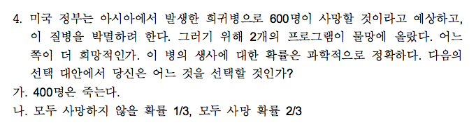

600명 중 200명이 사는 거나 400명이 죽는 것, 모두 살리는 거나 모두 죽지 않는 것이나 같은 내용임에도 반응이 다르게 나타남에 유의. 손실회피 경향과 같은 현상을 관찰할 수 있음.

#### 집계

|  | 확실히 | 확률적으로 | 결석 | 계 |
| --- | --- | --- | --- | --- |
| **생존 프레임** | 23 | 13 | 4 | 40 |
| **사망 프레임** | 15 | 21 | 2 | 38 |
| **계** | 38 | 34 | 6 | 78 |

Pearson’s Chi-squared test with Yates’ continuity correction: `.`

| Test statistic | df | P value |
| --- | --- | --- |
| 2.731 | 1 | 0.09844 |

#### % 비교.

|  | 확실히 | 확률적으로 | 계 |
| --- | --- | --- | --- |
| **생존 프레임** | 63.9 | 36.1 | 100.0 |
| **사망 프레임** | 41.7 | 58.3 | 100.0 |

## 디폴트 효과

### 표시하지 않으면 … 으로 간주합니다의 효과

#### Red

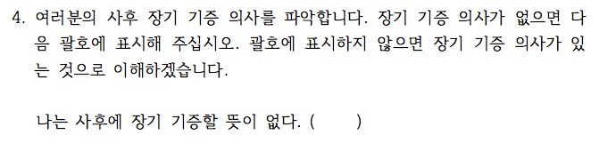

#### Black

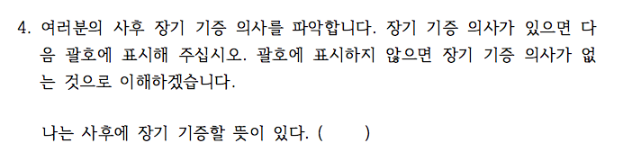

표시하지 않으면 장기 기증의사가 있는 것으로 간주하는 경우(Red)와 표시하면 장기 기증의사가 있는 것으로 간주하는 경우(Black), 표시하지 않으면 기증 의사가 있다고 보는 질문지에 기증 의사 비율이 더 높게 나오는 것으로 알려져 있는데 숫자 상으로는 차이가 나지만 통계적으로 유의한 수준은 아닙니다.

#### 집계

|  | 있음 | 없음 | 불참 | 결석 | 계 |
| --- | --- | --- | --- | --- | --- |
| **Red** | 23 | 13 | 0 | 4 | 40 |
| **Black** | 20 | 17 | 0 | 1 | 38 |
| **계** | 43 | 30 | 0 | 5 | 78 |

Pearson’s Chi-squared test: `.`

| Test statistic | df | P value |
| --- | --- | --- |
| 0.7873 | 2 | 0.6746 |

#### % 비교.

|  | 있음 | 없음 | 계 |
| --- | --- | --- | --- |
| **Red** | 63.9 | 36.1 | 100.0 |
| **Black** | 54.1 | 45.9 | 100.0 |

#### 합산(%)

|  | 있음 | 없음 | 계 |
| --- | --- | --- | --- |
| **계** | 58.9 | 41.1 | 100.0 |

### Thinking, Fast and Slow

#### Article

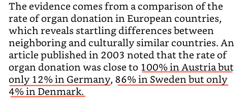

#### Facts Found

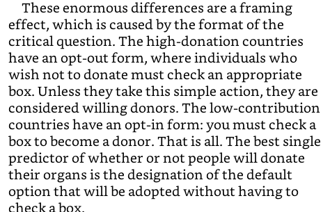